# Titanic - Machine Learning from Disaster

Name: Elad Shoham

ID: 206001752

Kaggle: https://www.kaggle.com/eladshoham

# About the competition

The sinking of the Titanic is one of the most infamous shipwrecks in history.  On April 15, 1912, during her maiden voyage, the widely considered “unsinkable” RMS Titanic sank after colliding with an iceberg. Unfortunately, there weren’t enough lifeboats for everyone onboard, resulting in the death of 1502 out of 2224 passengers and crew.  While there was some element of luck involved in surviving, it seems some groups of people were more likely to survive than others.  In this competiton, I built a predictive model that answers the question: “what sorts of people were more likely to survive?”, by using passenger data (ie name, age, gender, socio-economic class, etc).  We will perform several experiments on different models with different divisions of data to find the model that will bring the highest accuracy and the lowest cross entropy loss.

# Imports and Definitions

```python
# import numpy, matplotlib, etc.
import math
import numpy as np
import pandas as pd
import seaborn as sns
import matplotlib.pyplot as plt

# sklearn imports
import sklearn
from sklearn import metrics
from sklearn import datasets
from sklearn import pipeline
from sklearn import linear_model
from sklearn import preprocessing
from sklearn import model_selection
from sklearn import neural_network
from sklearn.preprocessing import OneHotEncoder

# define plt settings
sns.set_theme()
plt.rcParams["font.size"] = 20
plt.rcParams["axes.labelsize"] = 20
plt.rcParams["xtick.labelsize"] = 20
plt.rcParams["ytick.labelsize"] = 20
plt.rcParams["legend.fontsize"] = 20
plt.rcParams["legend.markerscale"] = 1.5
plt.rcParams["figure.figsize"] = (12, 10)
plt.rcParams["legend.title_fontsize"] = 20
```

# Data Investigation and Preprocessing

```python
train = pd.read_csv("/content/train.csv")
test = pd.read_csv("/content/test.csv")
submission = pd.read_csv("/content/gender_submission.csv")

train
```

|  | PassengerId | Survived | Pclass | Name | Sex | Age | SibSp | Parch | Ticket | Fare | Cabin | Embarked |
| --- | --- | --- | --- | --- | --- | --- | --- | --- | --- | --- | --- | --- |
| 0 | 1 | 0 | 3 | Braund, Mr. Owen Harris | male | 22.0 | 1 | 0 | A/5 21171 | 7.2500 | NaN | S |
| 1 | 2 | 1 | 1 | Cumings, Mrs. John Bradley (Florence Briggs Th... | female | 38.0 | 1 | 0 | PC 17599 | 71.2833 | C85 | C |
| 2 | 3 | 1 | 3 | Heikkinen, Miss. Laina | female | 26.0 | 0 | 0 | STON/O2. 3101282 | 7.9250 | NaN | S |
| 3 | 4 | 1 | 1 | Futrelle, Mrs. Jacques Heath (Lily May Peel) | female | 35.0 | 1 | 0 | 113803 | 53.1000 | C123 | S |
| 4 | 5 | 0 | 3 | Allen, Mr. William Henry | male | 35.0 | 0 | 0 | 373450 | 8.0500 | NaN | S |
| ... | ... | ... | ... | ... | ... | ... | ... | ... | ... | ... | ... | ... |
| 886 | 887 | 0 | 2 | Montvila, Rev. Juozas | male | 27.0 | 0 | 0 | 211536 | 13.0000 | NaN | S |
| 887 | 888 | 1 | 1 | Graham, Miss. Margaret Edith | female | 19.0 | 0 | 0 | 112053 | 30.0000 | B42 | S |
| 888 | 889 | 0 | 3 | Johnston, Miss. Catherine Helen "Carrie" | female | NaN | 1 | 2 | W./C. 6607 | 23.4500 | NaN | S |
| 889 | 890 | 1 | 1 | Behr, Mr. Karl Howell | male | 26.0 | 0 | 0 | 111369 | 30.0000 | C148 | C |
| 890 | 891 | 0 | 3 | Dooley, Mr. Patrick | male | 32.0 | 0 | 0 | 370376 | 7.7500 | NaN | Q |

891 rows × 12 columns

**Data Dictionary**

| Variable | Definition | Key |
| --- | --- | --- |
| survival | Survival | 0 = No, 1 = Yes |
| pclass | Ticket class | 1 = 1st, 2 = 2nd, 3 = 3rd |
| sex | Sex |  |
| Age | Age in years |  |
| sibsp | # of siblings / spouses aboard the Titanic |  |
| parch | # of parents / children aboard the Titanic |  |
| ticket | Ticket number |  |
| fare | Passenger fare |  |
| cabin | Cabin number |  |
| embarked | Port of Embarkation | C = Cherbourg, Q = Queenstown, S = Southampton |

```python
# fill empty values in the dataframe by the median of the column
def fill_na_median(df, column_name):
  df_not_null = df[~df[column_name].isnull()]
  df[column_name].fillna(df_not_null[column_name].median(), inplace=True)

# fill empty values in the dataframe by random value from the column
def fill_na_random_pick_column_distribution(df, column_name):
  df_not_null = df[~df[column_name].isnull()]
  df_null = df[df[column_name].isnull()]
  options = np.random.choice(df_not_null[column_name])
  df[column_name] = df[column_name].apply(lambda x: np.random.choice(df_not_null[column_name]) if pd.isnull(x) else x)
```

```python
# count empty values in each column
def count_empty_values_in_each_column(df: pd.DataFrame):
  print('empty values')
  print('------------\n')

  for col in df.columns:
    print(f"{col}: {df[col].isna().sum()}")
```

**Preprocessing on train data**

```python
# clean unnecessary column such as PassengerId, Name and Ticket from train
train = train.drop(['PassengerId', 'Name', 'Ticket'], axis=1)
train
```

|  | Survived | Pclass | Sex | Age | SibSp | Parch | Fare | Cabin | Embarked |
| --- | --- | --- | --- | --- | --- | --- | --- | --- | --- |
| 0 | 0 | 3 | male | 22.0 | 1 | 0 | 7.2500 | NaN | S |
| 1 | 1 | 1 | female | 38.0 | 1 | 0 | 71.2833 | C85 | C |
| 2 | 1 | 3 | female | 26.0 | 0 | 0 | 7.9250 | NaN | S |
| 3 | 1 | 1 | female | 35.0 | 1 | 0 | 53.1000 | C123 | S |
| 4 | 0 | 3 | male | 35.0 | 0 | 0 | 8.0500 | NaN | S |
| ... | ... | ... | ... | ... | ... | ... | ... | ... | ... |
| 886 | 0 | 2 | male | 27.0 | 0 | 0 | 13.0000 | NaN | S |
| 887 | 1 | 1 | female | 19.0 | 0 | 0 | 30.0000 | B42 | S |
| 888 | 0 | 3 | female | NaN | 1 | 2 | 23.4500 | NaN | S |
| 889 | 1 | 1 | male | 26.0 | 0 | 0 | 30.0000 | C148 | C |
| 890 | 0 | 3 | male | 32.0 | 0 | 0 | 7.7500 | NaN | Q |

891 rows × 9 columns

```python
# check if there is missing data in train data
count_empty_values_in_each_column(train)
```

```
empty values
------------

Survived: 0
Pclass: 0
Sex: 0
Age: 177
SibSp: 0
Parch: 0
Fare: 0
Cabin: 687
Embarked: 2
```

```python
# completion of missing values in train
fill_na_median(train, 'Age')
fill_na_random_pick_column_distribution(train, 'Cabin')
fill_na_random_pick_column_distribution(train, 'Embarked')
train
```

|  | Survived | Pclass | Sex | Age | SibSp | Parch | Fare | Cabin | Embarked |
| --- | --- | --- | --- | --- | --- | --- | --- | --- | --- |
| 0 | 0 | 3 | male | 22.0 | 1 | 0 | 7.2500 | C46 | S |
| 1 | 1 | 1 | female | 38.0 | 1 | 0 | 71.2833 | C85 | C |
| 2 | 1 | 3 | female | 26.0 | 0 | 0 | 7.9250 | F33 | S |
| 3 | 1 | 1 | female | 35.0 | 1 | 0 | 53.1000 | C123 | S |
| 4 | 0 | 3 | male | 35.0 | 0 | 0 | 8.0500 | E121 | S |
| ... | ... | ... | ... | ... | ... | ... | ... | ... | ... |
| 886 | 0 | 2 | male | 27.0 | 0 | 0 | 13.0000 | C101 | S |
| 887 | 1 | 1 | female | 19.0 | 0 | 0 | 30.0000 | B42 | S |
| 888 | 0 | 3 | female | 28.0 | 1 | 2 | 23.4500 | B96 B98 | S |
| 889 | 1 | 1 | male | 26.0 | 0 | 0 | 30.0000 | C148 | C |
| 890 | 0 | 3 | male | 32.0 | 0 | 0 | 7.7500 | C90 | Q |

891 rows × 9 columns

```python
# checking if all the missing data in train is now completed
count_empty_values_in_each_column(train)
```

```
empty values
------------

Survived: 0
Pclass: 0
Sex: 0
Age: 0
SibSp: 0
Parch: 0
Fare: 0
Cabin: 0
Embarked: 0
```

```python
# using LabelEncoder from sklearn to change Cabin and Embarked to numbers depanding their lables
lb = sklearn.preprocessing.LabelEncoder()
train['Cabin'] = lb.fit_transform(train['Cabin'])
train['Embarked'] = lb.fit_transform(train['Embarked'])

# using OneHotEncoder from sklearn to change Sex to 0/1 values.
enc = OneHotEncoder(sparse=False, drop='first')
train_cat = train[['Sex']]
train_cat_enc = pd.DataFrame(enc.fit_transform(train_cat), columns=enc.get_feature_names())
train = train.drop(['Sex'], axis=1).join(train_cat_enc) # remove Sex column and concations the encoding column
train
```

|  | Survived | Pclass | Age | SibSp | Parch | Fare | Cabin | Embarked | x0_male |
| --- | --- | --- | --- | --- | --- | --- | --- | --- | --- |
| 0 | 0 | 3 | 22.0 | 1 | 0 | 7.2500 | 67 | 2 | 1.0 |
| 1 | 1 | 1 | 38.0 | 1 | 0 | 71.2833 | 81 | 0 | 0.0 |
| 2 | 1 | 3 | 26.0 | 0 | 0 | 7.9250 | 142 | 2 | 0.0 |
| 3 | 1 | 1 | 35.0 | 1 | 0 | 53.1000 | 55 | 2 | 0.0 |
| 4 | 0 | 3 | 35.0 | 0 | 0 | 8.0500 | 118 | 2 | 1.0 |
| ... | ... | ... | ... | ... | ... | ... | ... | ... | ... |
| 886 | 0 | 2 | 27.0 | 0 | 0 | 13.0000 | 48 | 2 | 1.0 |
| 887 | 1 | 1 | 19.0 | 0 | 0 | 30.0000 | 30 | 2 | 0.0 |
| 888 | 0 | 3 | 28.0 | 1 | 2 | 23.4500 | 47 | 2 | 0.0 |
| 889 | 1 | 1 | 26.0 | 0 | 0 | 30.0000 | 60 | 0 | 1.0 |
| 890 | 0 | 3 | 32.0 | 0 | 0 | 7.7500 | 84 | 1 | 1.0 |

891 rows × 9 columns

**Preprocessing on test data**

```python
# clean unnecessary column such as PassengerId, Name and Ticket from test
test = test.drop(['PassengerId', 'Name', 'Ticket'], axis=1)
test
```

|  | Pclass | Sex | Age | SibSp | Parch | Fare | Cabin | Embarked |
| --- | --- | --- | --- | --- | --- | --- | --- | --- |
| 0 | 3 | male | 34.5 | 0 | 0 | 7.8292 | NaN | Q |
| 1 | 3 | female | 47.0 | 1 | 0 | 7.0000 | NaN | S |
| 2 | 2 | male | 62.0 | 0 | 0 | 9.6875 | NaN | Q |
| 3 | 3 | male | 27.0 | 0 | 0 | 8.6625 | NaN | S |
| 4 | 3 | female | 22.0 | 1 | 1 | 12.2875 | NaN | S |
| ... | ... | ... | ... | ... | ... | ... | ... | ... |
| 413 | 3 | male | NaN | 0 | 0 | 8.0500 | NaN | S |
| 414 | 1 | female | 39.0 | 0 | 0 | 108.9000 | C105 | C |
| 415 | 3 | male | 38.5 | 0 | 0 | 7.2500 | NaN | S |
| 416 | 3 | male | NaN | 0 | 0 | 8.0500 | NaN | S |
| 417 | 3 | male | NaN | 1 | 1 | 22.3583 | NaN | C |

418 rows × 8 columns

```python
# check if there is missing data in test data
count_empty_values_in_each_column(test)
```

```
empty values
------------

Pclass: 0
Sex: 0
Age: 86
SibSp: 0
Parch: 0
Fare: 1
Cabin: 327
Embarked: 0
```

```python
# completion of missing values in test
fill_na_median(test, 'Age')
fill_na_median(test, 'Fare')
fill_na_random_pick_column_distribution(test, 'Cabin')
test
```

|  | Pclass | Sex | Age | SibSp | Parch | Fare | Cabin | Embarked |
| --- | --- | --- | --- | --- | --- | --- | --- | --- |
| 0 | 3 | male | 34.5 | 0 | 0 | 7.8292 | F33 | Q |
| 1 | 3 | female | 47.0 | 1 | 0 | 7.0000 | E52 | S |
| 2 | 2 | male | 62.0 | 0 | 0 | 9.6875 | D40 | Q |
| 3 | 3 | male | 27.0 | 0 | 0 | 8.6625 | C46 | S |
| 4 | 3 | female | 22.0 | 1 | 1 | 12.2875 | C55 C57 | S |
| ... | ... | ... | ... | ... | ... | ... | ... | ... |
| 413 | 3 | male | 27.0 | 0 | 0 | 8.0500 | E50 | S |
| 414 | 1 | female | 39.0 | 0 | 0 | 108.9000 | C105 | C |
| 415 | 3 | male | 38.5 | 0 | 0 | 7.2500 | B36 | S |
| 416 | 3 | male | 27.0 | 0 | 0 | 8.0500 | C53 | S |
| 417 | 3 | male | 27.0 | 1 | 1 | 22.3583 | B57 B59 B63 B66 | C |

418 rows × 8 columns

```python
# checking if all the missing data in test is now completed
count_empty_values_in_each_column(test)
```

```
empty values
------------

Pclass: 0
Sex: 0
Age: 0
SibSp: 0
Parch: 0
Fare: 0
Cabin: 0
Embarked: 0
```

```python
# using LabelEncoder from sklearn to change Cabin and Embarked to numbers depanding their lables
test['Cabin'] = lb.fit_transform(test['Cabin'])
test['Embarked'] = lb.fit_transform(test['Embarked'])

# using OneHotEncoder from sklearn to change Sex to 0/1 values.
enc = OneHotEncoder(sparse=False, drop='first')
test_cat = test[['Sex']]
test_cat_enc = pd.DataFrame(enc.fit_transform(test_cat), columns=enc.get_feature_names())
test = test.drop(['Sex'], axis=1).join(test_cat_enc) # remove Sex column and concations the encoding column
test
```

|  | Pclass | Age | SibSp | Parch | Fare | Cabin | Embarked | x0_male |
| --- | --- | --- | --- | --- | --- | --- | --- | --- |
| 0 | 3 | 34.5 | 0 | 0 | 7.8292 | 73 | 1 | 1.0 |
| 1 | 3 | 47.0 | 1 | 0 | 7.0000 | 66 | 2 | 0.0 |
| 2 | 2 | 62.0 | 0 | 0 | 9.6875 | 58 | 1 | 1.0 |
| 3 | 3 | 27.0 | 0 | 0 | 8.6625 | 33 | 2 | 1.0 |
| 4 | 3 | 22.0 | 1 | 1 | 12.2875 | 37 | 2 | 0.0 |
| ... | ... | ... | ... | ... | ... | ... | ... | ... |
| 413 | 3 | 27.0 | 0 | 0 | 8.0500 | 65 | 2 | 1.0 |
| 414 | 1 | 39.0 | 0 | 0 | 108.9000 | 22 | 0 | 0.0 |
| 415 | 3 | 38.5 | 0 | 0 | 7.2500 | 10 | 2 | 1.0 |
| 416 | 3 | 27.0 | 0 | 0 | 8.0500 | 35 | 2 | 1.0 |
| 417 | 3 | 27.0 | 1 | 1 | 22.3583 | 15 | 0 | 1.0 |

418 rows × 8 columns

# Features Engineering

```python
# get color map
def get_sns_cmap(n, name='muted'):
  return sns.color_palette(palette=name, n_colors=n)

# plot with regression line target values by each feature
def plot_reg_target_values_by_each_feature(df, target_column_name):
  nrows = math.ceil(math.sqrt(len(df.columns)-1))
  ncols = math.ceil((len(df.columns)-1)/nrows)
  fig, axes = plt.subplots(nrows, ncols)
  plt.subplots_adjust(top=4.0, bottom=0, left=0, right=2.5)
  colors = get_sns_cmap(len(df.columns))

  for i in range(len(df.columns)):
    ax = sns.regplot(x=df.columns[i], y=target_column_name, data=df, color=colors[i], ax=axes[i//nrows, i%nrows], scatter_kws={"s": 40})
    ax.set_title(label=f'{df.columns[i]} by {target_column_name}', fontsize=10)

  for i in range(len(df.columns), nrows*ncols):
    fig.delaxes(axes.flatten()[i])
```

```python
# show absolute correlation between features in a heatmap
def show_heatmap(data):
  plt.figure(figsize=(18,10))
  cor = np.abs(data.corr())
  sns.heatmap(cor, annot=True, cmap=plt.cm.Purples, vmin=-1, vmax=1)
  plt.show()
```

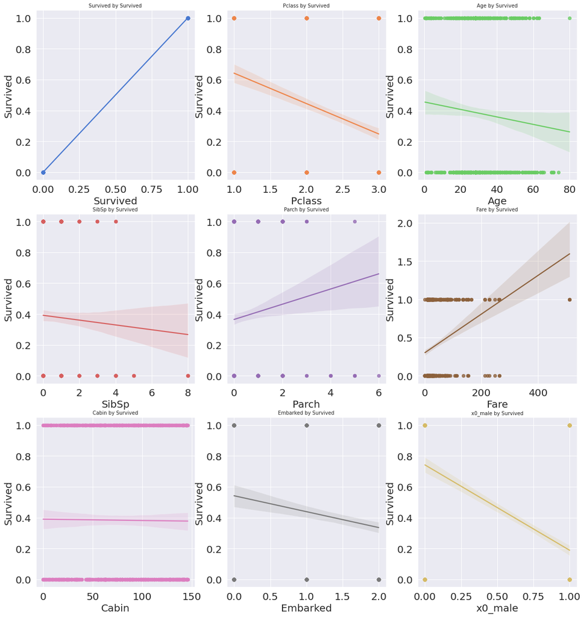

```python
plot_reg_target_values_by_each_feature(train, 'Survived')
```

It hard to say which of the features have the best correlation with the target but it seem like that the x0_male have a good correlation with the target.

Let's plot a heatmap of the correlation table between the features.

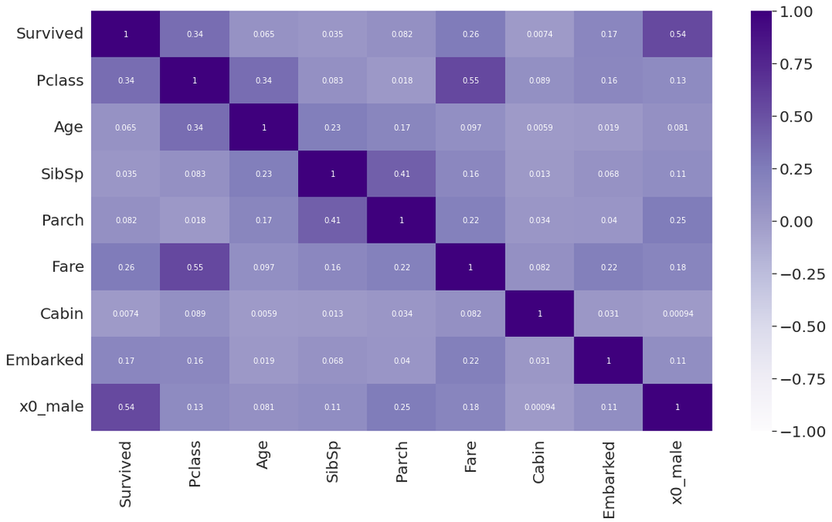

```python
# showing heatmap of the train data
show_heatmap(train)
```

As we expected x0_male has a really good correlation to the goal, in addition there seems to be a good correlation between Fare and Pclass and there is some connection between them so we will try to create a new feature from them as FarePerPclass as follows:

FarePerPclass = Fare / Pclass

```python
# adding FarePerPclass to train_cp data
train_cp = train.copy()
train_cp.insert(len(train.columns), 'FarePerPclass', train_cp['Fare'] / train_cp['Pclass'])

# adding FarePerPclass to test_cp data
test_cp = test.copy()
test_cp.insert(len(test.columns), 'FarePerPclass', test_cp['Fare'] / test_cp['Pclass'])
```

```python
train_cp
```

|  | Survived | Pclass | Age | SibSp | Parch | Fare | Cabin | Embarked | x0_male | FarePerPclass |
| --- | --- | --- | --- | --- | --- | --- | --- | --- | --- | --- |
| 0 | 0 | 3 | 22.0 | 1 | 0 | 7.2500 | 67 | 2 | 1.0 | 2.416667 |
| 1 | 1 | 1 | 38.0 | 1 | 0 | 71.2833 | 81 | 0 | 0.0 | 71.283300 |
| 2 | 1 | 3 | 26.0 | 0 | 0 | 7.9250 | 142 | 2 | 0.0 | 2.641667 |
| 3 | 1 | 1 | 35.0 | 1 | 0 | 53.1000 | 55 | 2 | 0.0 | 53.100000 |
| 4 | 0 | 3 | 35.0 | 0 | 0 | 8.0500 | 118 | 2 | 1.0 | 2.683333 |
| ... | ... | ... | ... | ... | ... | ... | ... | ... | ... | ... |
| 886 | 0 | 2 | 27.0 | 0 | 0 | 13.0000 | 48 | 2 | 1.0 | 6.500000 |
| 887 | 1 | 1 | 19.0 | 0 | 0 | 30.0000 | 30 | 2 | 0.0 | 30.000000 |
| 888 | 0 | 3 | 28.0 | 1 | 2 | 23.4500 | 47 | 2 | 0.0 | 7.816667 |
| 889 | 1 | 1 | 26.0 | 0 | 0 | 30.0000 | 60 | 0 | 1.0 | 30.000000 |
| 890 | 0 | 3 | 32.0 | 0 | 0 | 7.7500 | 84 | 1 | 1.0 | 2.583333 |

891 rows × 10 columns

```python
test_cp
```

|  | Pclass | Age | SibSp | Parch | Fare | Cabin | Embarked | x0_male | FarePerPclass |
| --- | --- | --- | --- | --- | --- | --- | --- | --- | --- |
| 0 | 3 | 34.5 | 0 | 0 | 7.8292 | 73 | 1 | 1.0 | 2.609733 |
| 1 | 3 | 47.0 | 1 | 0 | 7.0000 | 66 | 2 | 0.0 | 2.333333 |
| 2 | 2 | 62.0 | 0 | 0 | 9.6875 | 58 | 1 | 1.0 | 4.843750 |
| 3 | 3 | 27.0 | 0 | 0 | 8.6625 | 33 | 2 | 1.0 | 2.887500 |
| 4 | 3 | 22.0 | 1 | 1 | 12.2875 | 37 | 2 | 0.0 | 4.095833 |
| ... | ... | ... | ... | ... | ... | ... | ... | ... | ... |
| 413 | 3 | 27.0 | 0 | 0 | 8.0500 | 65 | 2 | 1.0 | 2.683333 |
| 414 | 1 | 39.0 | 0 | 0 | 108.9000 | 22 | 0 | 0.0 | 108.900000 |
| 415 | 3 | 38.5 | 0 | 0 | 7.2500 | 10 | 2 | 1.0 | 2.416667 |
| 416 | 3 | 27.0 | 0 | 0 | 8.0500 | 35 | 2 | 1.0 | 2.683333 |
| 417 | 3 | 27.0 | 1 | 1 | 22.3583 | 15 | 0 | 1.0 | 7.452767 |

418 rows × 9 columns

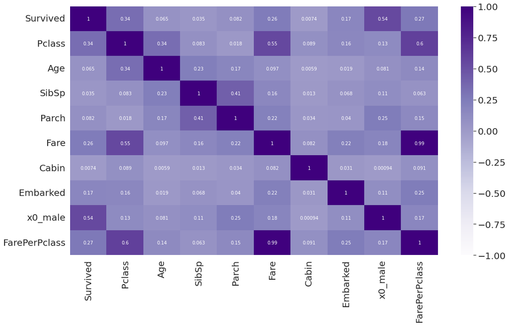

```python
# showing heatmap of the copy train data with the new feature FarePerPclass
show_heatmap(train_cp)
```

The absolute correlation between the new FarePerPclass attribute and the target is 0.27, relative to other attributes in the train data, this attribute is considered a good correlation to the target, so we will try to integrate train_cp in the experiment in the next step.

# Data Slicing

```python
# print 4 graphs: ce of train/test and r2 of train/test
def print_graphs_r2_ce(graph_points):
  for k, v in graph_points.items():
    best_value = max(v.values()) if 'R2' in k else min(v.values())
    best_index = np.argmax(list(v.values())) if 'R2' in k else np.argmin(list(v.values()))
    color = 'r' if 'train' in k else 'b'
    plt.rcParams["figure.figsize"] = (16, 8)
    plt.plot(list(v.keys()), list(v.values()), color)
    plt.grid()
    plt.xlabel('X')
    plt.ylabel('Y')
    plt.title(f'{k}, best value: x={best_index + 1}, y={best_value}', fontsize=20)
    plt.show()
```

```python
# plot the score by split and the loss by split for SGD
def plot_score_and_loss_by_split_SGD(x, t):
  graph_points = { 'train_CE': {}, 'val_CE': {}, 'train_R2': {}, 'val_R2': {} }

  for size in range(10, 100, 10):
    x_train, x_val, t_train, t_val = model_selection.train_test_split(x, t, test_size=size/100, random_state=42)
    SGD_cls = pipeline.make_pipeline(preprocessing.StandardScaler(), linear_model.SGDClassifier(loss='log', alpha=0, learning_rate='constant', eta0=0.01)).fit(x_train, t_train)
    y_train_prob = SGD_cls.predict_proba(x_train)
    y_test_prob = SGD_cls.predict_proba(x_val)
    y_train = SGD_cls.predict(x_train)
    y_val = SGD_cls.predict(x_val)
    graph_points['train_CE'][size/100] = metrics.log_loss(t_train, y_train_prob)
    graph_points['val_CE'][size/100] = metrics.log_loss(t_val, y_test_prob)
    graph_points['train_R2'][size/100] = SGD_cls.score(x_train, t_train)
    graph_points['val_R2'][size/100] = SGD_cls.score(x_val, t_val)
  print_graphs_r2_ce(graph_points)
```

```python
# plot the score by split and the loss by split for MLP
def plot_score_and_loss_by_split_MLP(x, t):
  graph_points = { 'train_CE': {}, 'val_CE': {}, 'train_R2': {}, 'val_R2': {} }

  for size in range(10, 100, 10):
    x_train, x_val, t_train, t_val = model_selection.train_test_split(x, t, test_size=size/100, random_state=42)
    MLP_cls = neural_network.MLPClassifier(activation='logistic', solver='sgd', alpha=0, max_iter=40000).fit(x_train, t_train)
    y_train_prob = MLP_cls.predict_proba(x_train)
    y_test_prob = MLP_cls.predict_proba(x_val)
    graph_points['train_CE'][size/100] = metrics.log_loss(t_train, y_train_prob)
    graph_points['val_CE'][size/100] = metrics.log_loss(t_val, y_test_prob)
    graph_points['train_R2'][size/100] = MLP_cls.score(x_train, t_train)
    graph_points['val_R2'][size/100] = MLP_cls.score(x_val, t_val)
  print_graphs_r2_ce(graph_points)
```

We can now check the train and train_cp on 2 models, SGDClassifier and MLP, and check which of the models and the cross section of the data for training and validation will result in the highest level of accuracy and lower cross entropy loss.

**Regular Train Data**

```python
# divide the train data to features and target
t = train['Survived'].copy()
x = train.drop(['Survived'], axis=1)
print('t')
display(t)
print()
print('x')
display(x)
```

```
t
```

```
0      0
1      1
2      1
3      1
4      0
      ..
886    0
887    1
888    0
889    1
890    0
Name: Survived, Length: 891, dtype: int64
```

```
x
```

|  | Pclass | Age | SibSp | Parch | Fare | Cabin | Embarked | x0_male |
| --- | --- | --- | --- | --- | --- | --- | --- | --- |
| 0 | 3 | 22.0 | 1 | 0 | 7.2500 | 67 | 2 | 1.0 |
| 1 | 1 | 38.0 | 1 | 0 | 71.2833 | 81 | 0 | 0.0 |
| 2 | 3 | 26.0 | 0 | 0 | 7.9250 | 142 | 2 | 0.0 |
| 3 | 1 | 35.0 | 1 | 0 | 53.1000 | 55 | 2 | 0.0 |
| 4 | 3 | 35.0 | 0 | 0 | 8.0500 | 118 | 2 | 1.0 |
| ... | ... | ... | ... | ... | ... | ... | ... | ... |
| 886 | 2 | 27.0 | 0 | 0 | 13.0000 | 48 | 2 | 1.0 |
| 887 | 1 | 19.0 | 0 | 0 | 30.0000 | 30 | 2 | 0.0 |
| 888 | 3 | 28.0 | 1 | 2 | 23.4500 | 47 | 2 | 0.0 |
| 889 | 1 | 26.0 | 0 | 0 | 30.0000 | 60 | 0 | 1.0 |
| 890 | 3 | 32.0 | 0 | 0 | 7.7500 | 84 | 1 | 1.0 |

891 rows × 8 columns

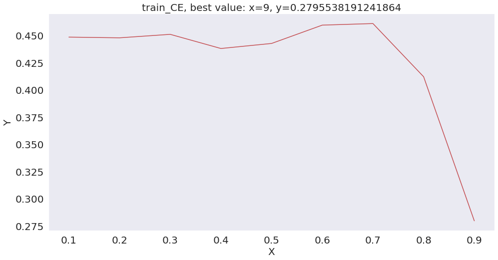

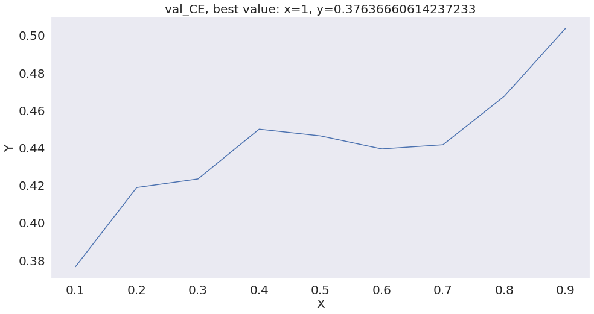

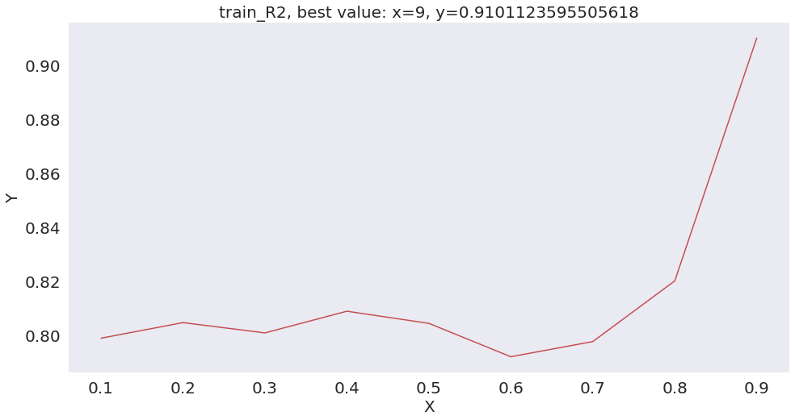

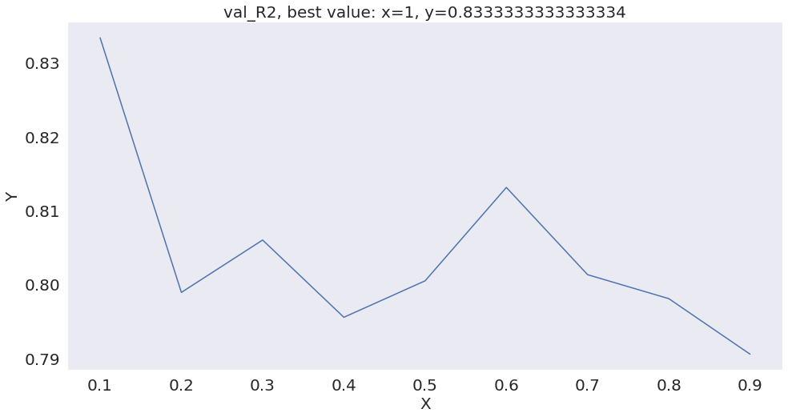

```python
# plot the train on SGD model be different slicing of the data
plot_score_and_loss_by_split_SGD(x, t)
```

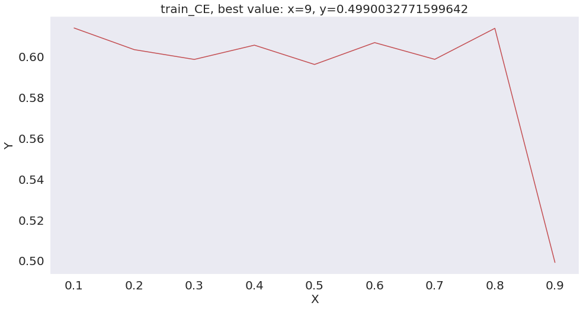

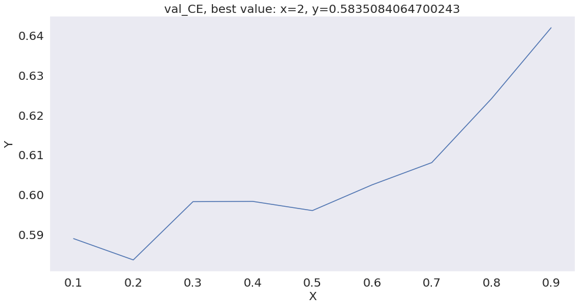

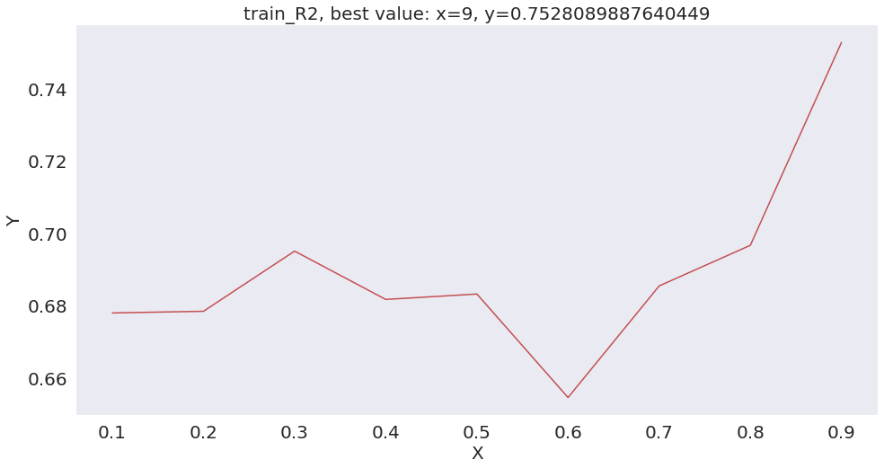

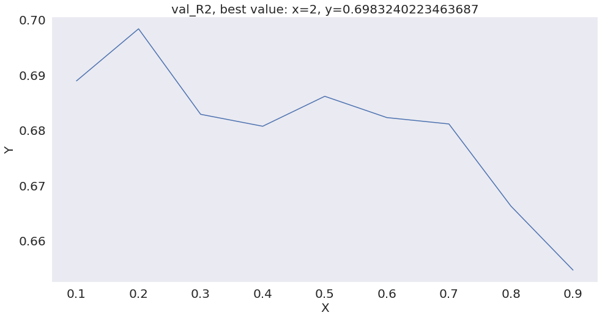

```python
# plot the train on MLP model be different slicing of the data
plot_score_and_loss_by_split_MLP(x, t)
```

**Train Copy Data (with FarePerPclass feature)**

```python
# divide the train_cp data to features and target
t_cp = train_cp['Survived'].copy()
x_cp = train_cp.drop(['Survived'], axis=1)
print('t')
display(t_cp)
print()
print('x')
display(x_cp)
```

```
t
```

```
0      0
1      1
2      1
3      1
4      0
      ..
886    0
887    1
888    0
889    1
890    0
Name: Survived, Length: 891, dtype: int64
```

```
x
```

|  | Pclass | Age | SibSp | Parch | Fare | Cabin | Embarked | x0_male | FarePerPclass |
| --- | --- | --- | --- | --- | --- | --- | --- | --- | --- |
| 0 | 3 | 22.0 | 1 | 0 | 7.2500 | 67 | 2 | 1.0 | 2.416667 |
| 1 | 1 | 38.0 | 1 | 0 | 71.2833 | 81 | 0 | 0.0 | 71.283300 |
| 2 | 3 | 26.0 | 0 | 0 | 7.9250 | 142 | 2 | 0.0 | 2.641667 |
| 3 | 1 | 35.0 | 1 | 0 | 53.1000 | 55 | 2 | 0.0 | 53.100000 |
| 4 | 3 | 35.0 | 0 | 0 | 8.0500 | 118 | 2 | 1.0 | 2.683333 |
| ... | ... | ... | ... | ... | ... | ... | ... | ... | ... |
| 886 | 2 | 27.0 | 0 | 0 | 13.0000 | 48 | 2 | 1.0 | 6.500000 |
| 887 | 1 | 19.0 | 0 | 0 | 30.0000 | 30 | 2 | 0.0 | 30.000000 |
| 888 | 3 | 28.0 | 1 | 2 | 23.4500 | 47 | 2 | 0.0 | 7.816667 |
| 889 | 1 | 26.0 | 0 | 0 | 30.0000 | 60 | 0 | 1.0 | 30.000000 |
| 890 | 3 | 32.0 | 0 | 0 | 7.7500 | 84 | 1 | 1.0 | 2.583333 |

891 rows × 9 columns

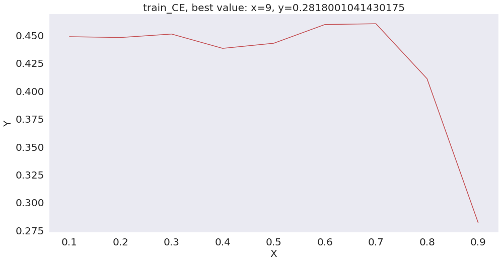

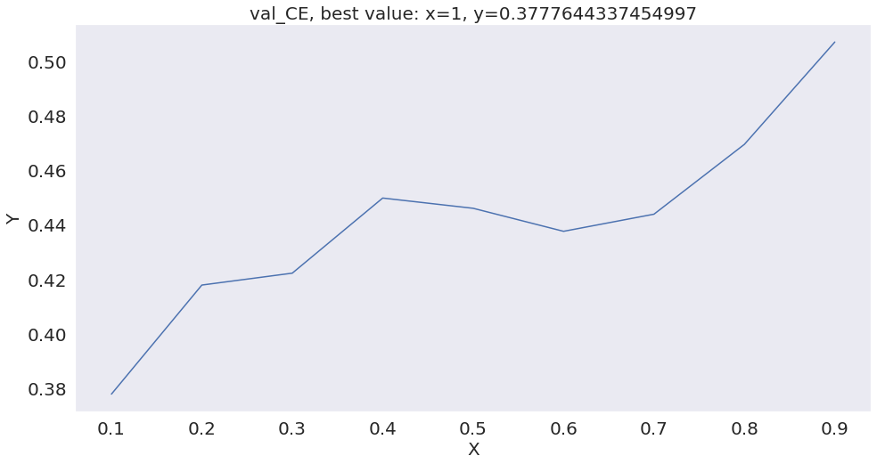

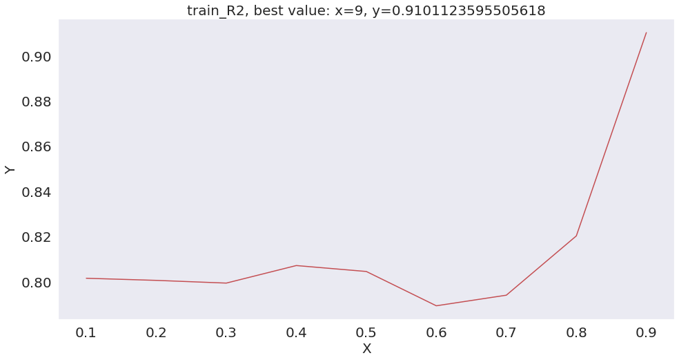

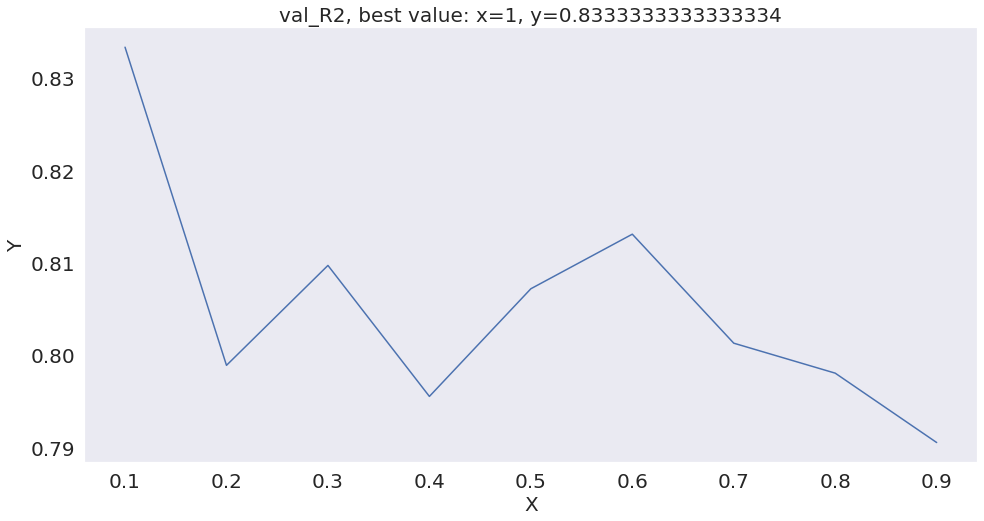

```python
# plot the train_cp on SGD model be different slicing of the data
plot_score_and_loss_by_split_SGD(x_cp, t_cp)
```

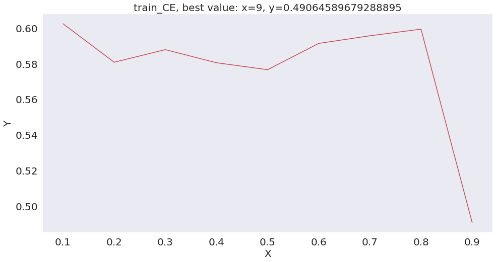

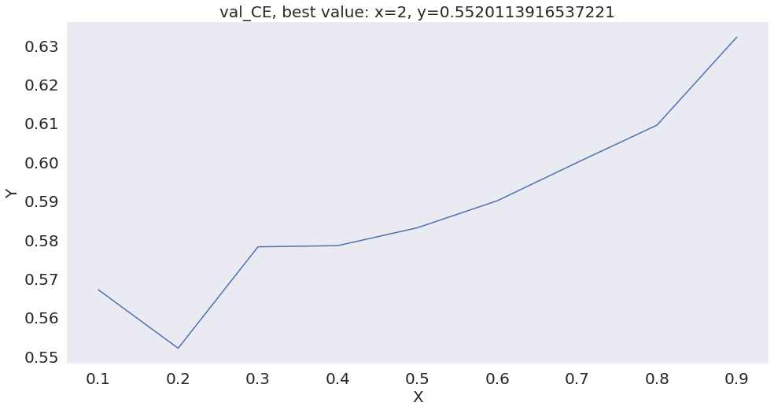

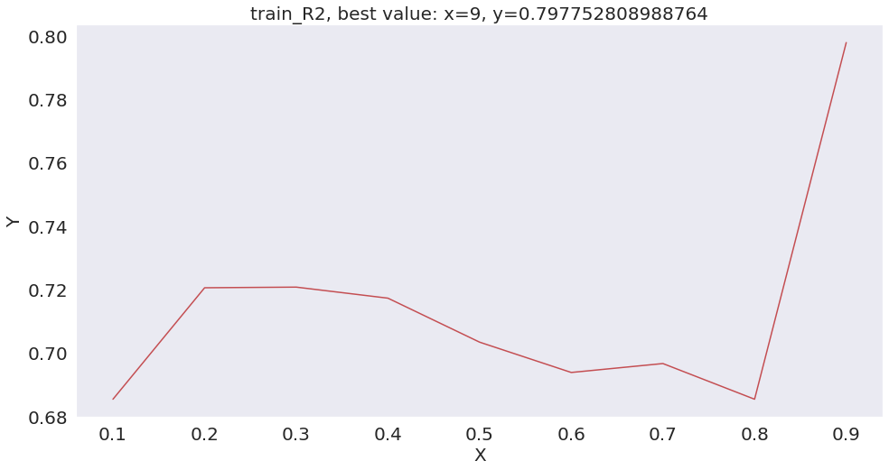

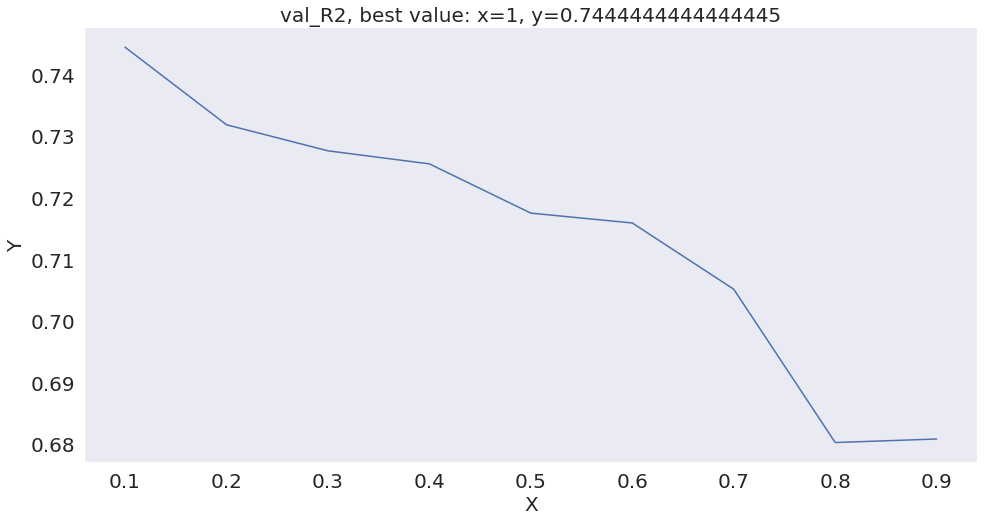

```python
# plot the train_cp on MLP model be different slicing of the data
plot_score_and_loss_by_split_MLP(x_cp, t_cp)
```

**Results**

It can be seen that the SGDClassifier model gives better results than MLP in all cases.

# Classification

```python
# split the train data to 75% train and 25% validation
x_train, x_val, t_train, t_val = model_selection.train_test_split(x, t, test_size=0.25, random_state=42)
```

```python
# create the SGDClassifier and predict the probabilities of the train and test data
SGD_cls = pipeline.make_pipeline(preprocessing.StandardScaler(), linear_model.SGDClassifier(loss='log', alpha=0, learning_rate='constant', eta0=0.01)).fit(x_train, t_train)
y_train_prob = SGD_cls.predict_proba(x_train)
y_test_prob = SGD_cls.predict_proba(x_val)
y_train = SGD_cls.predict(x_train)
y_test = SGD_cls.predict(x_val)

# print the accuracy score and CE loss of the train and test
print('Accuracy score on train', SGD_cls.score(x_train, t_train))
print('Accuracy score on test', SGD_cls.score(x_val, t_val))
print()
print('CE on train', metrics.log_loss(t_train, y_train_prob))
print('CE on test', metrics.log_loss(t_val, y_test_prob))
```

```
Accuracy score on train 0.8053892215568862
Accuracy score on test 0.8026905829596412

CE on train 0.4488955492026428
CE on test 0.4209333462718659
```

```python
# predict the test with SGDClassifier
SGD_cls = pipeline.make_pipeline(preprocessing.StandardScaler(), linear_model.SGDClassifier(loss='log', alpha=0, learning_rate='constant', eta0=0.01)).fit(x, t)
submission_preds = SGD_cls.predict(test)
```

```python
# create the submission file
submission['Survived'] = submission_preds
submission.to_csv('submission.csv', index=False)
submission
```

|  | PassengerId | Survived |
| --- | --- | --- |
| 0 | 892 | 0 |
| 1 | 893 | 0 |
| 2 | 894 | 0 |
| 3 | 895 | 0 |
| 4 | 896 | 1 |
| ... | ... | ... |
| 413 | 1305 | 0 |
| 414 | 1306 | 1 |
| 415 | 1307 | 0 |
| 416 | 1308 | 0 |
| 417 | 1309 | 0 |

418 rows × 2 columns

# Submissions and Leaderboard

**My Submissions**

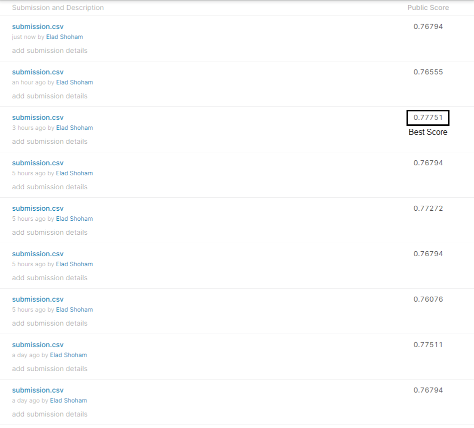

**Leaderboard**

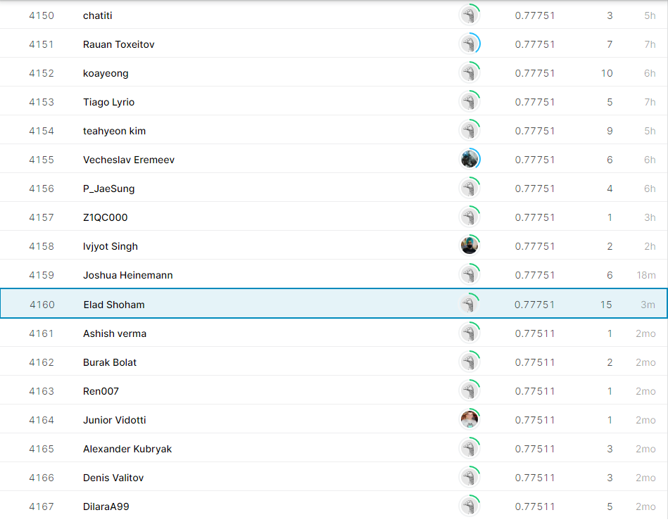

# Conclusions

# References

sklrean - https://scikit-learn.org/stable/

for read the data - https://www.kaggle.com/jlawman/complete-beginner-your-first-titanic-submission